### 空間分析 作業6

#### 地理二 B06208001 龔泓愷

```r
library(ggplot2)
library(rgdal)
library(GISTools)
library(sp)
library(aspace)
library(dplyr)
Temp <- readOGR(dsn = "./data", layer = "Tempcycle_twd97", encoding="utf8") #TWD97
TWN <- readOGR(dsn = "./data", layer = "Popn_TWN2", encoding="utf8") #TWD97
```

> Q1-1：決定其中一間媽祖寺廟，如何使所有信眾的直線距離總和最小化？

```r
# CENTRAL FEATURE
Temp.Ma <- filter(Temp@data, 主祭神祇 == "媽祖")
Temp.Ma.CF <- CF(id = 1, points = Temp.Ma[,8:9])
```

```
##   id     CF.x    CF.y
## 1  1 199423.9 2610921
```

```r
droplevels(filter(Temp.Ma, X_n == Temp.Ma.CF[,2])[,5])
```

```
## [1] 泰寧宮
## Levels: 泰寧宮
```

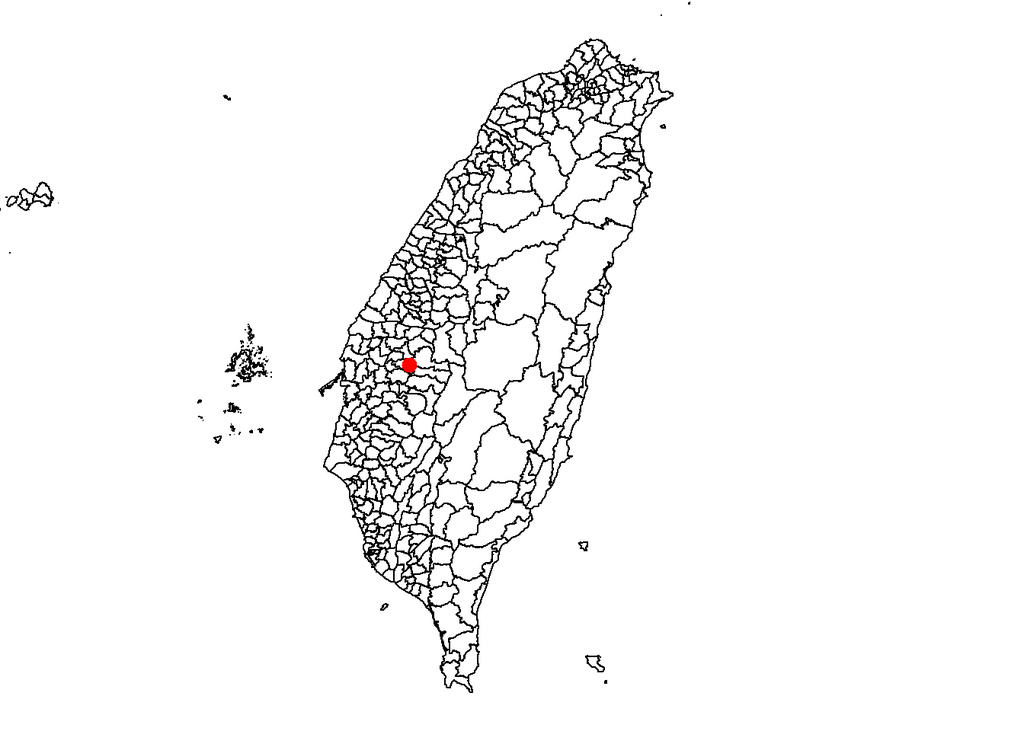

```r
# 製作CF點資料
Temp.Ma.CF <- SpatialPoints(cbind(Temp.Ma.CF[,2], Temp.Ma.CF[,3]), proj4string = TWN@proj4string)
# 畫圖
par(mar = c(0,0,0,0))
plot(TWN, xlim=c(148466,368986), ylim=c(2415399,2806277))
points(Temp.Ma.CF, col = "red", pch = 20, cex = 2)
```

> Q1-2：另外搭設繞境中心，中心應設在何處？

```r
Temp.Ma.Med <- median_centre(points = Temp.Ma[,8:9])
```

```
##   id median.x median.y
## 1  1 198975.8  2616313
```

```r
# 製作點資料
Temp.Ma.Med <- SpatialPoints(cbind(Temp.Ma.Med[,2], Temp.Ma.Med[,3]), proj4string = TWN@proj4string)
# 和台灣取交集
vill.index <- gIntersection(TWN,Temp.Ma.Med, byid = T)
vill.index <- as.numeric(unlist(lapply(strsplit(row.names(vill.index), " "), function(x) x[1]))) #VILL ID
droplevels(TWN@data[vill.index+1,2])
```

```
## [1] 斗南鎮
## Levels: 斗南鎮
```

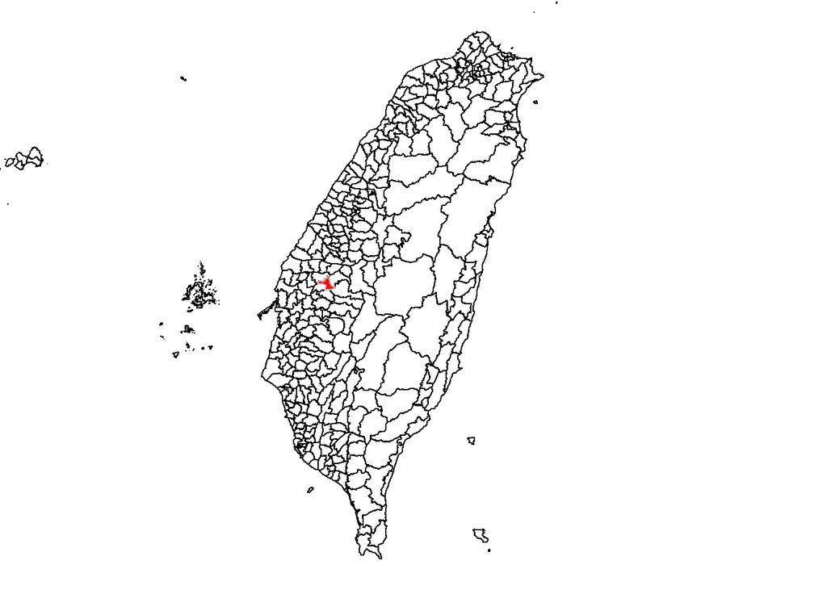

```r
# 畫圖
vill.Med <- TWN[vill.index+1,]
par(mar = c(0,0,0,0))
plot(TWN, xlim=c(148466,368986), ylim=c(2415399,2806277))
plot(vill.Med, col = 'red', border = 'grey', add = T)
```

> Q2-1：比較對於信仰「媽祖」與「觀音菩薩」信眾的空間分佈差異。

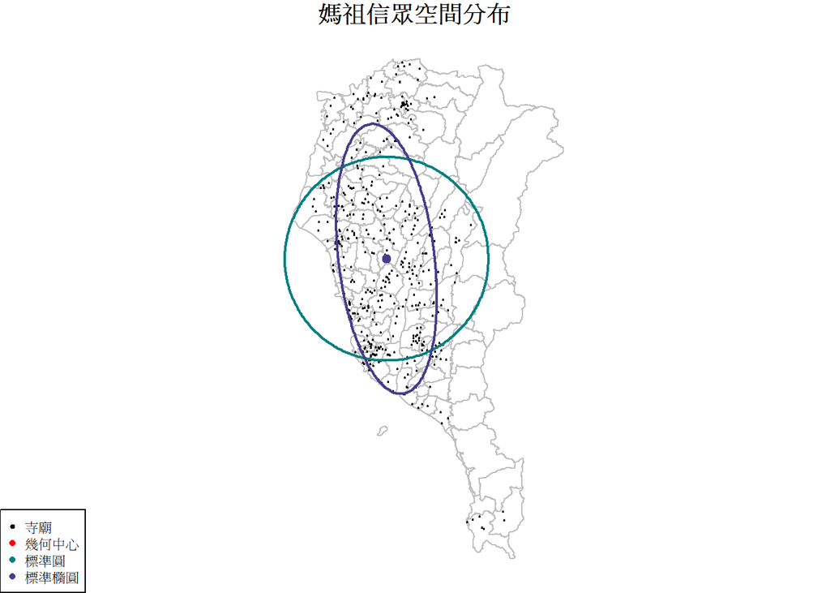

```r
# 挑出要的資料
Temp.S <- Temp[Temp$COUNTYNAME %in% c("嘉義縣", "嘉義市", "高雄市", "高雄縣", "台南市","台南縣", "屏東縣", "屏東市"),]
TWN.S <- TWN[TWN$COUNTY %in% c("嘉義縣", "嘉義市", "高雄市", "臺南市", "屏東縣", "屏東市"),]

Temp.S.M <- subset(Temp.S, 主祭神祇 == "媽祖") #挑出南部媽祖

# 畫圖
par(mar = c(0,0,1,0))
plot(TWN.S, xlim=c(127367,267976), ylim=c(2416990,2620214), border = "grey", main = "媽祖信眾空間分布")
points(Temp.S.M, pch = 20, cex = 0.3)#所有廟的點

# 幾何中心
M.mea <- mean_centre(points = Temp.S.M@data[,8:9])
points(M.mea$CENTRE.x, M.mea$CENTRE.y, col="red", cex=1.4, pch=20)

# 標準圓
M.sdd <- calc_sdd(points = Temp.S.M@data[,8:9])
plot_sdd(plotnew = FALSE, plotcentre = T, centre.col = "#008080",
         sdd.col = "#008080", sdd.lwd = 2, titletxt = "", plotpoints = F)

# 標準橢圓
M.sde <- calc_sde(points = Temp.S.M@data[,8:9])
plot_sde(plotnew = FALSE, plotcentre = T, centre.col = "#483D8B",
         sde.col = "#483D8B", sde.lwd = 2, titletxt = "", plotpoints = F)

legend("bottomleft", legend = c('寺廟','幾何中心','標準圓', '標準橢圓'), pch = c(20,16,16,16), col = c("black","red","#008080","#483D8B"), cex=0.7)
```

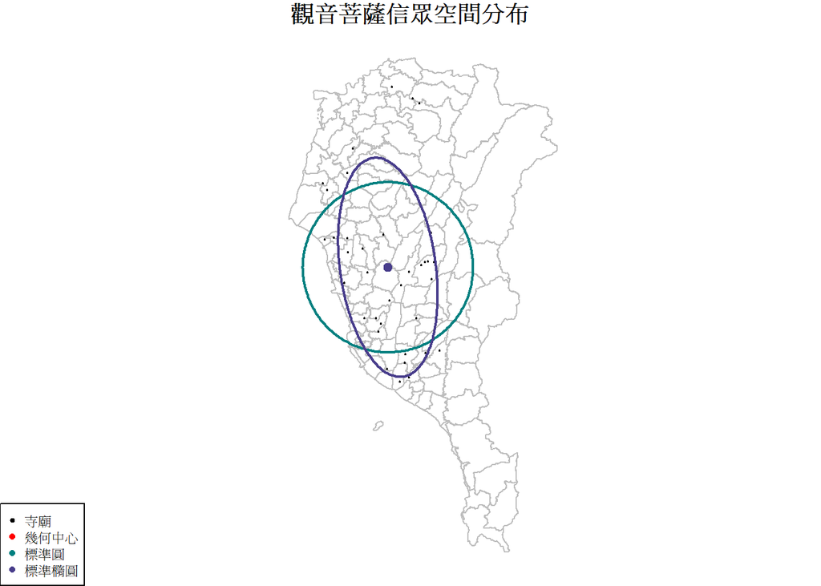

```r
Temp.S.K <- subset(Temp.S, 主祭神祇 == "觀音菩薩") #挑出南部媽祖

# 畫圖
par(mar = c(0,0,1,0))
plot(TWN.S, xlim=c(127367,267976), ylim=c(2416990,2620214), border = "grey", main = "觀音菩薩信眾空間分布")
points(Temp.S.K, pch = 20, cex = 0.3)#所有廟的點

# 幾何中心
K.mea <- mean_centre(points = Temp.S.K@data[,8:9])
points(K.mea$CENTRE.x, K.mea$CENTRE.y, col="red", cex=1.4, pch=20)

# 標準圓
K.sdd <- calc_sdd(points = Temp.S.K@data[,8:9])
plot_sdd(plotnew = FALSE, plotcentre = T, centre.col = "#008080",
         sdd.col = "#008080", sdd.lwd = 2, titletxt = "", plotpoints = F)

# 標準橢圓
K.sde <- calc_sde(points = Temp.S.K@data[,8:9])
plot_sde(plotnew = FALSE, plotcentre = T, centre.col = "#483D8B",
         sde.col = "#483D8B", sde.lwd = 2, titletxt = "", plotpoints = F)

legend("bottomleft", legend = c('寺廟','幾何中心','標準圓', '標準橢圓'), pch = c(20,16,16,16), col = c("black","red","#008080","#483D8B"), cex=0.7)
```

> Q2-2：以20 km x 20 km的網格，比較信仰「媽祖」與「觀音菩薩」的寺廟的空間群聚特性，並討論之。

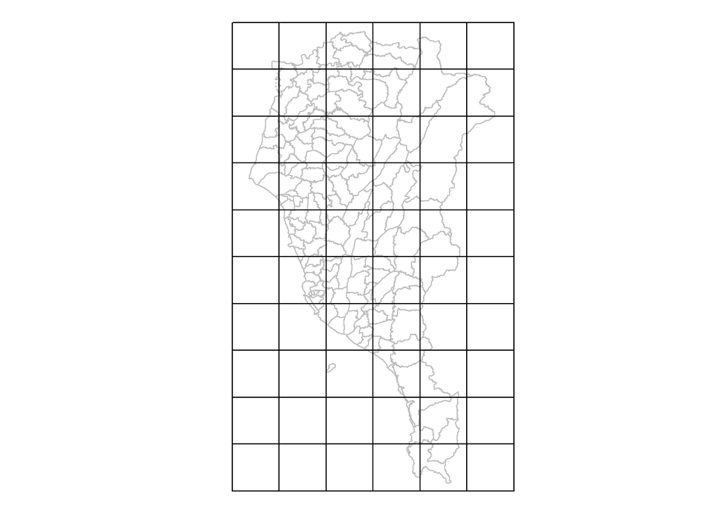

```r
# 製作Grid
grd <- GridTopology(cellcentre.offset=c(153113.6,2428667),
                    cellsize=c(20000,20000), cells.dim = c(6,10))
grd <- SpatialPolygonsDataFrame(as.SpatialPolygons.GridTopology(grd, proj4string = TWN@proj4string), data = data.frame(c(1:60)), match.ID = FALSE)

# 畫出來檢查看看
par(mar = c(0,0,0,0))
plot(TWN.S, xlim=c(127367,267976), ylim=c(2416990,2620214), border = "grey")
plot(grd, add = T)
```

```r
# 算VMR
counts.M = poly.counts(Temp.S.M, grd)
mean.M <- mean(counts.M); var.M <- var(counts.M)
VMR.M <- var.M/mean.M; VMR.M
```

```
## [1] 23.19233
```

```r
counts.K = poly.counts(Temp.S.K, grd)
mean.K <- mean(counts.K); var.K <- var(counts.K)
VMR.K <- var.K/mean.K; VMR.K
```

```
## [1] 3.209634
```

#### 媽祖Quadrat Analysis

*Step1*  
H0：VMR = 1，空間群聚特性為隨機  
H1：VMR > 1  
alpha = 0.05

*Step2*

```r
s.e. = sqrt(2/59) #s.e.公式：sqrt(2/(k-1))，k格子數
t_value = (VMR.M - 1)/s.e. #VMR的null值 = 1
t_value
```

```
## [1] 120.5352
```

*Step3*

```r
p_value = pt(t_value, df = 59, lower.tail = F) #DF = 格子數 - 1
p_value
```

```
## [1] 1.309139e-72
```

*Step4*

```r
p_value < alpha
```

```
## [1] TRUE
```

由於P-value小於顯著水準(0.05)，拒絕虛無假設

*Step5*  
檢定結果為統計上顯著，因此媽祖的空間群聚特性應為群聚

#### 觀音菩薩Quadrat Analysis

*Step1*  
H0：VMR = 1，空間群聚特性為隨機  
H1：VMR > 1  
alpha = 0.05

*Step2*

```r
s.e. = sqrt(2/59) #s.e.公式：sqrt(2/(k-1))，k格子數
t_value = (VMR.K - 1)/s.e. #VMR的null值 = 1
t_value
```

```
## [1] 12.00139
```

*Step3*

```r
p_value = pt(t_value, df = 59, lower.tail = F) #DF = 格子數 - 1
p_value
```

```
## [1] 8.958338e-18
```

*Step4*

```r
p_value < alpha
```

```
## [1] TRUE
```

由於P-value小於顯著水準(0.05)，拒絕虛無假設

*Step5*  
檢定結果為統計上顯著，因此觀音菩薩的空間群聚特性應為群聚

在顯著水準為0.05下，媽祖與觀音菩薩皆屬於群聚，若細看兩者的VMR值，則可發現媽祖的VMR值更大，比觀音菩薩更接近群聚。

> Q2-3：比較20 km x 20 km vs.50 km x 50 km的網格，計算信仰「媽祖」寺廟的空間群聚特性的差異，並討論網格尺度對於檢定空間群聚之影響。

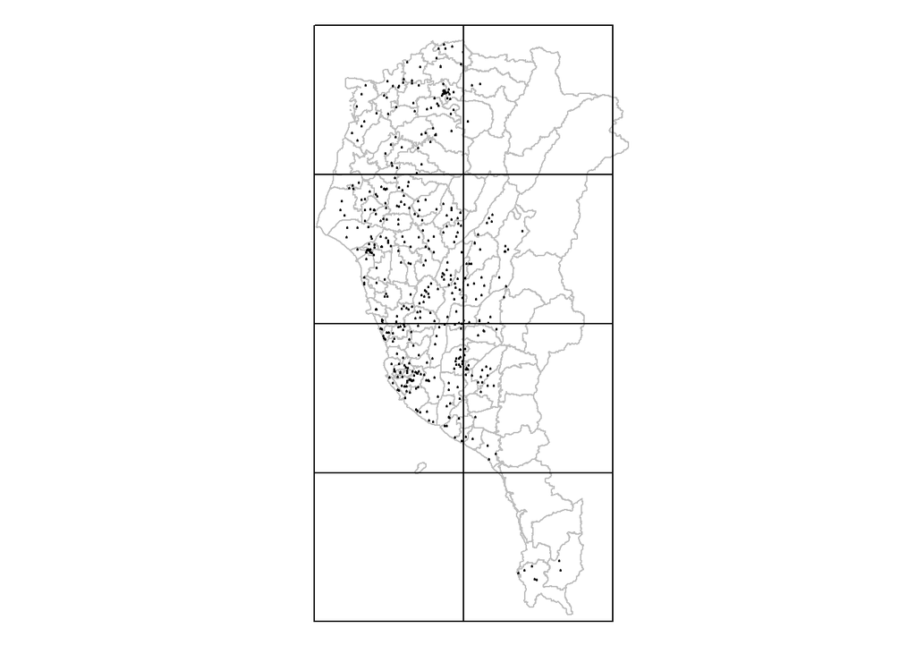

```r
# 製作Grid
grd <- GridTopology(cellcentre.offset=c(174613.6,2444667),
                    cellsize=c(50000,50000), cells.dim = c(2,4))
grd <- SpatialPolygonsDataFrame(as.SpatialPolygons.GridTopology(grd, proj4string = TWN@proj4string), data = data.frame(c(1:8)), match.ID = FALSE)

# 畫出來檢查看看
par(mar = c(0,0,0,0))
plot(TWN.S, xlim=c(127367,267976), ylim=c(2416990,2620214), border = "grey")
points(Temp.S.M, pch = 20, cex = 0.3)#所有廟的點
plot(grd, add = T)
```

```r
# 算VMR
counts.M = poly.counts(Temp.S.M, grd)
mean.M <- mean(counts.M); var.M <- var(counts.M)
VMR.M <- var.M/mean.M; VMR.M
```

```
## [1] 67.89294
```

*Step1*  
H0：VMR = 1，空間群聚特性為隨機  
H1：VMR > 1  
alpha = 0.05

*Step2*

```r
s.e. = sqrt(2/7) #s.e.公式：sqrt(2/(k-1))，k格子數
t_value = (VMR.M - 1)/s.e. #VMR的null值 = 1
t_value
```

```
## [1] 125.1452
```

*Step3*

```r
p_value = pt(t_value, df = 7, lower.tail = F) #DF = 格子數 - 1
p_value
```

```
## [1] 2.743097e-13
```

*Step4*

```r
p_value < alpha
```

```
## [1] TRUE
```

由於P-value小於顯著水準(0.05)，拒絕虛無假設

*Step5*  
檢定結果為統計上顯著，因此媽祖的空間群聚特性應為群聚

網格尺度較大(50km X 50km)，與小尺度網格(20km X 20km)相較之下，數值為0的網格較少，也拉大了網格數值之間的差距，因此在大網格尺度下求得的VMR值，較小網格尺度的來得大，更加凸顯空間群聚的特性。